# Introduction to Machine Learning

## What is Machine Learning

Field of study that gives computers the ability to learn without being explicitly programmed

- Data science is used to gain insights and understanding of the data.
- Machine learning is used to produce predictions.

### Machine Learning helps us with Predictive Analytics and the below are the benefits

- We can calculate the probabilities of occurrence of specific results in the future and take corresponding actions.
- We can automate the process of tagging numerous items in the relevant Industry, which would have otherwise been only possible by involving a large amount of human labor.
- We can make real-time systems that trigger alarms before any significant accident occurs, predict the stock prices, work on several forecasting problems, and many more examples in an automated way.
- We can optimize many industrial processes and save time and money.

## Machine Learning Applications

Virtual Personal Assistants: Siri, Cortana, Alexa, Google Now

Finance: Fraud detection, prediction and execution of trades at speeds and volumes that humans can’t compete with.

Social Media: Face Recognition, People You May Know, Pages You Might Like.

Retail: Product Recommendations; maximization of revenue by learning customers’ habits.

Online customer support: Customer support representatives are being increasingly replaced by chatbots.

Medicine: Medical diagnosis, drug discovery, understanding of risk factors for diseases in large populations.

Search Results: When you search on Google, the backend keeps an eye on whether you clicked on the first result or went on to the second page -– the data is used to learn from mistakes so that relevant information can be found quicker next time.

[figure not shown]

## Types of Machine Learning

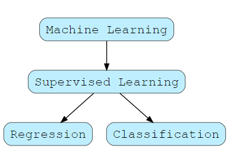

## 1. Supervised Learning

Supervised Machine Learning is an algorithm that learns from labeled training data to help you predict outcomes for unforeseen data.

In other words, the algorithm has a supervisor or a teacher who provides it with all the answers first, like whether it’s a cat in the picture or not. And the machine uses these examples to learn one by one. The spam filter is another good example of this.

Another typical task, of a different type would be to predict a target numeric value like housing prices from a set of features like size, location, number of bedrooms. To train the system, we again need to provide many correct examples of known housing prices, including both their features and their labels.

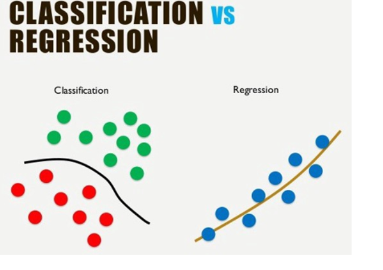

While categorizing emails or identifying whether the picture is of a cat or a dog was a supervised learning algorithm of type classification, predicting housing prices is known as regression. What’s the difference?

In regression the output is a continuous value or a decimal number like housing prices. In classification, the output is a label like “spam or not-spam” and not a decimal number; the output only takes values like 0 or 1 where we could have 1 for “spam” and 0 for “non-spam”.

### Classification Problem

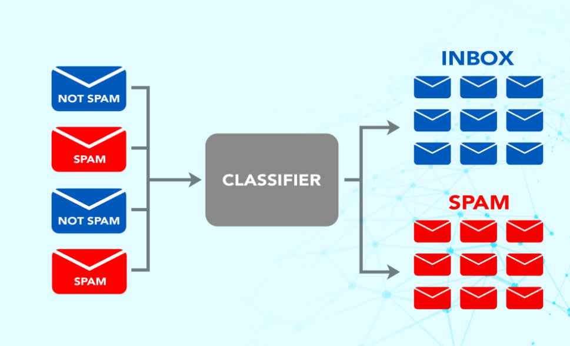

### Regression Model

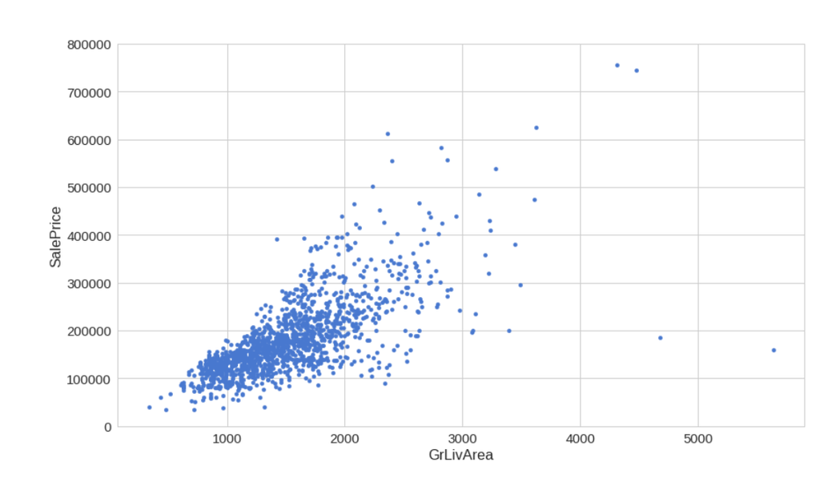

### Regression Problems involve predicting a continuous value output.

##### Some typical examples of Regression Problems are:

Predicting the house prices

Predicting the level of toxicity of comments

Predicting stock prices

Predicting the number of employees in a company

Predicting FVC measurement of patients

### Classification problems involve predicting a category output.

#### The output can draw from two categories (Binary classification), more than two categories (Multi-class classification). Some classification examples involve:

Predicting the sentiment of a tweet (positive or negative).

Predicting whether an X-Ray contains pneumonia or not.

Predicting the tumor of cancer as benign or malignant.

Predicting the weather of the coming days (hot or cold).

## 2.Unsupervised Machine Learning

In unsupervised learning, the dataset comes without pre-defined labeling, meaning it is unlabeled. The goal of unsupervised learning is to learn the pattern in the dataset with no supervision provided

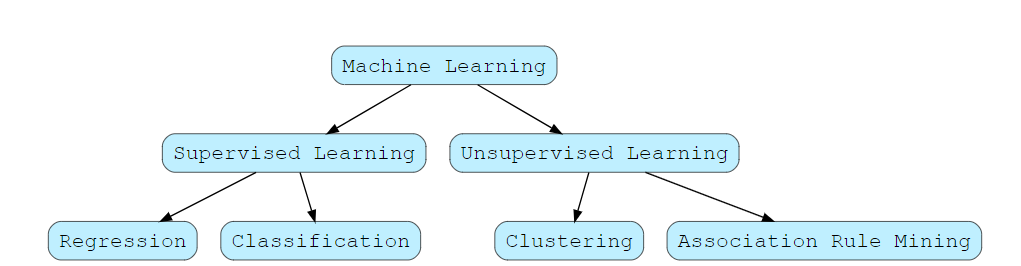

### Clustering

###### Clustering refers to the process of putting similar data items in the same group. The items in the same group or cluster are said to have the same label or ID. Clustering examples involve the following:

Clustering users based on their usage of social media

Clustering customers in a mall.

Clustering images and videos based on their content and other properties

Clustering newspaper articles and search results retrieved from a search engine having similar properties and content.

### Association rule mining

Association rule mining comes under the umbrella of Unsupervised Learning. Association rule mining helps us find features or dimensions, which occur together or are correlated.

Market Basket Analysis: It is a technique to discover association rules between items in retail shops.

Medical Diagnoses: Association Rule Mining helps in defining the relationship between symptoms and the corresponding diseases.

Bioinformatics: Association rule mining helps to understand the relationship between the occurrence of different amino acids in proteins.

## 3. Semi-Supervised Learning

Semi-supervised learning deals with partially labeled training data, usually a lot of unlabeled data with some labeled data. Most semi-supervised learning algorithms are a combination of unsupervised and supervised algorithms.

Google photos is a good example of this. In a set of family photos, the unsupervised part of the algorithm automatically recognizes the photos in which each of the family members appears. For example, it can tell that person A appears in picture 1 and 3 while person B appears in picture 1 and 2. After this step, all the system needs from us is one label for each person and then the supervised part of the algorithm can name everyone in every photo. Bingo!

## 4.Reinforcement Learning

Reinforcement Learning is a special and more advanced category where the learning system or agent needs to learn to make specific decisions. The agent observes the environment to which it is exposed, it selects and performs actions, and gets rewards or penalties in return. Its goal is to choose actions which maximize the reward over time. So, by trial and error, and based on past experience, the system learns the best strategy, called policy, on its own.

A good example of Reinforcement Learning is DeepMind’s AlphaGo. The system learned the winning policy at the game of Go by analyzing millions of games and then playing against itself. At the championship of Go in 2017, AlphaGo was able to beat the human world champion just by applying the policy it had learned earlier by itself.

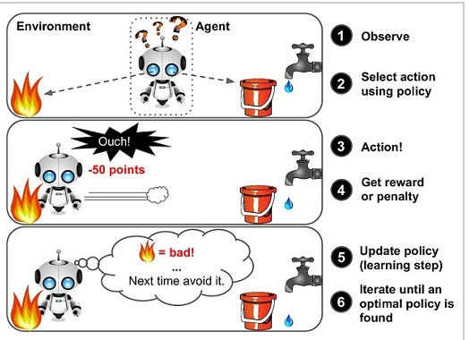

### Summary

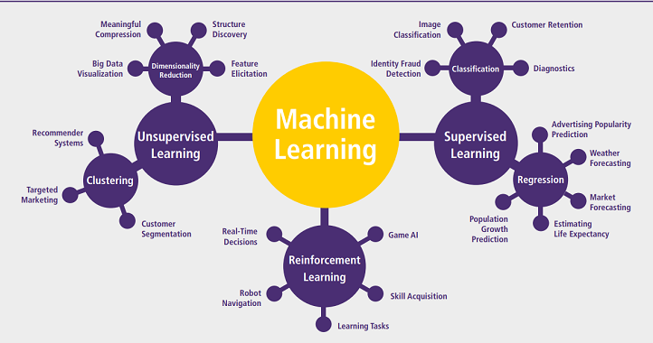

## Main Components of Machine Learning

### 1. Data

Data can be collected both manually and automatically. For example, users’ personal details like age and gender, all their clicks, and purchase history are valuable data for an online store. Data can be images, tables of data with many variables (features), text, sensor recordings, sound samples etc, depending on the problem at hand.

### 2. Features

Features are often also called variables. These are essentially the factors for a machine to look at — the properties of the “object” in question, e.g., users’ age, stock price, area of the rental properties, number of words in a sentence, petal length, size of the cells.

Choosing meaningful features is very important.For example if we want to distinguish apples from oranges, say we take bad features like ripeness and seed count. Since these are not really distinct properties of the fruits, our machine learning system won’t be able to do a good job at distinguishing between apples and oranges based on these features.

#### NB It takes practice and thought to figure out what features to use as they are not always as clear.

### 3.Algorithms

Algorithms refer to a set of computational procedures or processes that are designed to solve specific tasks or problems. These algorithms serve as the core components of machine learning models and enable them to learn patterns, make predictions, or take actions based on the provided data.

## Questions

- What is the difference between machine learning, data science and AI
- Can you explain the main components of a typical machine learning workflow?
- What is the Difference Between Supervised and Unsupervised Machine Learning?
- Research. How is Amazon Able to Recommend Other Things to Buy? How Does the Recommendation Engine Work?
- When Will You Use Classification over Regression?
- Considering a Long List of Machine Learning Algorithms, given a Data Set, How Do You Decide Which One to Use?
- What are some challenges or limitations of machine learning that you are aware of?
- Can you explain the main components of a typical machine learning workflow?